# NESE females: do repeat females keep their foraging pattern?

Luis Huckstadt & Sarah Peterson & Sarah Peterson

2026-11-11

# 1 Overview

This replaces `NESE_FemaleRepeatabilityIsotopes.Rmd`. The question — *do females tracked more than once keep their individual foraging pattern?* — is addressed with four complementary analyses:

1. **Strategy fidelity**: do repeat females keep the same strategy more often than expected by chance? (permutation test; Cohen’s κ)
2. **Behavioural repeatability**: repeatability (R) of the main behavioural axes and of interpretable variables, from mixed models with year as a random effect (`rptR`).
3. **Spatial fidelity**: is the overlap between two trips of the *same* female higher than between trips of *different* females? (randomisation test on utilisation distributions)
4. **Isotopic consistency**: population-level repeatability of δ¹³C and δ¹⁵N (adjusted for trip type, with year as a random effect), and a comparison of within-female isotopic differences with differences between different females sampled in the same years.

**What changed from the previous script, and why.** The “individual repeatability” index (between-individual variance / (between-individual variance + one seal’s residual variance)) is not a defined quantity: per-seal variances from 2–4 samples are extremely noisy, and conditional residuals from the mixed model are shrunk towards each seal’s mean, pushing the index towards 1. The previous script also attached those values to the wrong seals (`ddply` returns seals in alphabetical order, which were then relabelled in data order) and dropped one female through hard-coded row indices. Isotopes alone also cannot detect switching between the two offshore strategies, which are isotopically very similar. Repeatability is therefore estimated here only at the population level, and fidelity is tested directly on behaviour and space.

**Run first:** `NESE_PB_ForagingStrategies.Rmd`, `NESE_PM_ForagingStrategies.Rmd` (strategy assignments) and `NESE_SpatialStrategies.Rmd` (individual UDs).

```r
library(dplyr)
library(tidyr)
library(ggplot2)
library(rptR)
library(lme4)
```

# 2 Settings

```r
SEED <- 20261103
set.seed(SEED)

PCA_DATA    <- "../data/f.PCAdata.1.rds"
META_FILE   <- "../data/IsotopesDatasetForLuis_2023_4_4.csv"   # TOPPID -> MainID
REPEAT_DATA <- "../data/NESE_RepeatData.rds"                   # isotope samples (as in the old script)
PB_ASSIGN   <- "../results/PB_strategies/A_strategy_assignments.csv"
PM_ASSIGN   <- "../results/PM_strategies/A_strategy_assignments.csv"
UD_FILE     <- "../results/spatial_strategies/spatial_UDs.rds"

# Seals excluded from the isotope analysis in the original script
ISO_EXCLUDE <- c("RG180", "RG182", "RG184", "RG185", "RG187", "RG191")

N_PERM      <- 9999   # permutations / randomisations
N_RPT_BOOT  <- 1000   # rptR bootstrap replicates (CIs)
N_RPT_PERM  <- 1000   # rptR permutations (P-values)
MIN_REP_WITHIN <- 5   # minimum repeat females to estimate repeatability within one trip type

OUT <- "../results/female_consistency"
FIG <- "../figures/female_consistency"
dir.create(OUT, recursive = TRUE, showWarnings = FALSE)
dir.create(FIG, recursive = TRUE, showWarnings = FALSE)

BEHAV <- c("MaxLat_degrees", "MinLon_degrees", "MedianDistToContShelf_km", "SdDistContShelf_km",
           "MesoEcoProportionShelf", "MesoEcoProportionCAC", "MesoEcoProportionSubArcticPac",
           "MesoEcoProportionNorthCPac", "Mean_Depth_m", "Mean_Depth_sd", "Mean_Duration_sec",
           "Mean_Duration_sd", "Pct_TransitDives", "Pct_ForagingDives", "Pct_DriftDives",
           "Pct_BenthicDives", "PctTripDiving", "DeepDayForageDivesMedian_m",
           "DeepNightForageDivesMedian_m")
ISO <- c("d13C", "d15N")
TRIP_LAB <- c(PostBreeding = "PB", PostMolt = "PM")
```

## 2.1 Helper functions

```r
# Cohen's kappa for two vectors of categorical labels
cohen_kappa <- function(a, b) {
  lev <- union(a, b); a <- factor(a, lev); b <- factor(b, lev)
  tab <- table(a, b); n <- sum(tab)
  po <- sum(diag(tab)) / n; pe <- sum(rowSums(tab) * colSums(tab)) / n^2
  (po - pe) / (1 - pe)
}

# Fit rptR::rpt() without printing its progress bars into the report
fit_rpt <- function(...) {
  out <- NULL
  invisible(capture.output(out <- rpt(...)))
  out
}

# Read one random-effect component (e.g. "MainID") from rptR's printed summary.
# rptR's object layout differs between versions; the printed summary does not.
rpt_parse <- function(r, comp) {
  txt <- capture.output(print(summary(r)))
  i <- grep(paste0("^\\s*", comp, " \\("), txt)[1]
  if (is.na(i)) return(NULL)
  k <- grep("Repeatability estimation overview", txt)
  k <- k[k > i][1]
  if (is.na(k)) return(NULL)
  hdr  <- strsplit(trimws(txt[k + 1]), "\\s+")[[1]]
  vals <- suppressWarnings(as.numeric(strsplit(trimws(txt[k + 2]), "\\s+")[[1]]))
  if (length(hdr) != length(vals)) return(NULL)
  setNames(vals, hdr)
}

# One row of results: female repeatability (R, CI, P) and the share of variance due to year
rpt_row <- function(r, label, n_obs, n_ind, n_rep) {
  v  <- if (is.null(r)) NULL else rpt_parse(r, "MainID")
  vy <- if (is.null(r)) NULL else rpt_parse(r, "Year")
  g  <- function(x, nm) if (!is.null(x) && nm %in% names(x)) unname(x[[nm]]) else NA_real_
  if (is.null(v) && !is.null(r)) { message("Could not read R for ", label, "; full output:"); print(summary(r)) }
  data.frame(variable = label, n_obs = n_obs, n_females = n_ind, n_repeat_females = n_rep,
             R = g(v, "R"), SE = g(v, "SE"), lwr = g(v, "2.5%"), upr = g(v, "97.5%"),
             P_LRT = g(v, "LRT_P"), P_permut = g(v, "P_permut"),
             R_year = g(vy, "R"), P_LRT_year = g(vy, "LRT_P"))
}

# Draw one element at random (safe when x has length 1, unlike sample())
pick1 <- function(x) x[sample.int(length(x), 1)]

# All within-female pairs of rows of d (columns: MainID, TOPPID, trip, year, ...)
within_pairs <- function(d) {
  d %>% group_by(MainID) %>% filter(n() > 1) %>%
    group_modify(function(g, key) {
      ij <- t(combn(nrow(g), 2))
      data.frame(TOPPID_1 = g$TOPPID[ij[, 1]], TOPPID_2 = g$TOPPID[ij[, 2]],
                 trip_1 = g$trip[ij[, 1]], trip_2 = g$trip[ij[, 2]],
                 year_1 = g$year[ij[, 1]], year_2 = g$year[ij[, 2]])
    }) %>% ungroup() %>%
    mutate(pair_type = ifelse(trip_1 == trip_2, paste0(trip_1, "-", trip_2), "PB-PM"),
           lag_years = abs(year_2 - year_1))
}
```

# 3 Data

## 3.1 Tracked trips

```r
meta <- read.csv(META_FILE) %>%
  transmute(TOPPID = as.character(TOPPID), MainID = as.character(MainID)) %>%
  distinct(TOPPID, .keep_all = TRUE)

trk <- readRDS(PCA_DATA) %>%
  mutate(TOPPID = as.character(TOPPID)) %>%
  left_join(meta, by = "TOPPID") %>%
  mutate(trip = unname(TRIP_LAB[as.character(Trip)]),
         year = as.integer(as.character(ProcedureYear))) %>%
  filter(!is.na(MainID), !is.na(trip))

# Exclude trips with impossible values (as in the strategy scripts)
pct  <- grep("^Pct", BEHAV, value = TRUE); prop <- grep("^MesoEco", BEHAV, value = TRUE)
bad  <- apply(trk[pct], 1, function(x) any(x < 0 | x > 100)) |
        apply(trk[prop], 1, function(x) any(x < 0 | x > 1))
cat("Excluded trips with impossible values:", paste(trk$TOPPID[bad], collapse = ", "), "\n")
```

```
## Excluded trips with impossible values: 2013035
```

```r
trk <- trk[!bad & complete.cases(trk[BEHAV]), ]

# Strategy assignments
assign <- bind_rows(
  read.csv(PB_ASSIGN) %>% transmute(TOPPID = as.character(TOPPID), trip = "PB", strategy),
  read.csv(PM_ASSIGN) %>% transmute(TOPPID = as.character(TOPPID), trip = "PM", strategy))
trk <- trk %>% left_join(assign, by = c("TOPPID", "trip"))

rep_ids <- trk %>% count(MainID) %>% filter(n > 1) %>% pull(MainID)
cat(nrow(trk), "tracked trips from", n_distinct(trk$MainID), "females;",
    length(rep_ids), "females tracked more than once (",
    sum(trk$MainID %in% rep_ids), "trips)\n")
```

```
## 179 tracked trips from 157 females; 17 females tracked more than once ( 39 trips)
```

```r
pairs_trk <- within_pairs(trk %>% dplyr::select(MainID, TOPPID, trip, year))
table(pairs_trk$pair_type)
```

```
##
## PB-PB PB-PM PM-PM
##     6    17     4
```

```r
summary(pairs_trk$lag_years)
```

```
##    Min. 1st Qu.  Median    Mean 3rd Qu.    Max.
##   0.000   1.000   1.000   1.852   3.000   4.000
```

# 4 1. Strategy fidelity

For each pair of trips of the same female: did she use the same strategy? For PB–PM pairs, “same” means the same offshore region (the coastal strategy has no Post-Moult counterpart, so such pairs count as different). The null distribution shuffles strategy labels among all trips of the same trip type, which keeps how common each strategy is.

```r
lab <- setNames(trk$strategy, trk$TOPPID)
fid <- pairs_trk %>%
  mutate(s1 = lab[TOPPID_1], s2 = lab[TOPPID_2]) %>%
  filter(!is.na(s1), !is.na(s2)) %>%
  mutate(same = s1 == s2)
fid %>% dplyr::select(MainID, pair_type, year_1, s1, year_2, s2, same) %>% arrange(pair_type, MainID)
```

```
## # A tibble: 27 × 7
##    MainID pair_type year_1 s1                    year_2 s2                 same
##    <chr>  <chr>      <int> <chr>                  <int> <chr>              <lgl>
##  1 M778   PB-PB       2010 Subarctic               2011 Subarctic          TRUE
##  2 M780   PB-PB       2009 Subarctic               2010 Subarctic          TRUE
##  3 N796   PB-PB       2009 Subarctic               2010 Subarctic          TRUE
##  4 R148   PB-PB       2009 North Central Pacific   2010 North Central Pac… TRUE
##  5 R541   PB-PB       2009 North Central Pacific   2010 North Central Pac… TRUE
##  6 S126   PB-PB       2009 North Central Pacific   2013 North Central Pac… TRUE
##  7 1244   PB-PM       2011 California Current      2008 North Central Pac… FALSE
##  8 3960   PB-PM       2014 Subarctic               2016 North Central Pac… FALSE
##  9 4534   PB-PM       2013 North Central Pacific   2014 Subarctic          FALSE
## 10 4534   PB-PM       2013 North Central Pacific   2015 Subarctic          FALSE
## # ℹ 17 more rows
```

```r
types <- c(sort(unique(fid$pair_type)), "All pairs")
idx_by_trip <- split(seq_len(nrow(trk)), trk$trip)
set.seed(SEED)
null_same <- replicate(N_PERM, {
  s <- trk$strategy
  for (tp in names(idx_by_trip)) { ii <- idx_by_trip[[tp]]; ok <- ii[!is.na(s[ii])]; s[ok] <- sample(s[ok]) }
  sh <- setNames(s, trk$TOPPID)
  same <- sh[fid$TOPPID_1] == sh[fid$TOPPID_2]
  c(tapply(same, fid$pair_type, sum), `All pairs` = sum(same))
})
obs_same <- c(tapply(fid$same, fid$pair_type, sum), `All pairs` = sum(fid$same))
n_pairs  <- c(table(fid$pair_type), `All pairs` = nrow(fid))

fid_tab <- data.frame(pair_type = types, n_pairs = as.vector(n_pairs[types]),
  n_same = as.vector(obs_same[types]),
  expected = rowMeans(null_same)[types],
  P = sapply(types, function(t) (1 + sum(null_same[t, ] >= obs_same[t])) / (N_PERM + 1)),
  row.names = NULL)
fid_tab %>% mutate(across(c(expected, P), ~ signif(.x, 3)))
```

```
##   pair_type n_pairs n_same expected      P
## 1     PB-PB       6      6     2.63 0.0066
## 2     PB-PM      17     13     7.86 0.0110
## 3     PM-PM       4      4     2.00 0.0608
## 4 All pairs      27     23    12.50 0.0002
```

```r
# Cohen's kappa for pairs of the same trip type (first vs second trip)
kap <- fid %>% filter(pair_type != "PB-PM") %>% group_by(pair_type) %>%
  summarise(n = n(), kappa = if (n() >= 3) cohen_kappa(s1, s2) else NA_real_)
kap
```

```
## # A tibble: 2 × 3
##   pair_type     n kappa
##   <chr>     <int> <dbl>
## 1 PB-PB         6     1
## 2 PM-PM         4     1
```

```r
write.csv(fid_tab, file.path(OUT, "1_strategy_fidelity.csv"), row.names = FALSE)
write.csv(fid, file.path(OUT, "1_strategy_fidelity_pairs.csv"), row.names = FALSE)
```

## 4.1 Figure: strategy sequences of repeat females (Fig. 5a)

One row per female tracked more than once. Points are trips, coloured by strategy (circles = post-breeding, triangles = post-moult); post-moult trips are drawn half a year after the post-breeding trip of the same year. Solid lines join consecutive trips with the same strategy, dashed lines a change. Females that changed strategy are listed at the top.

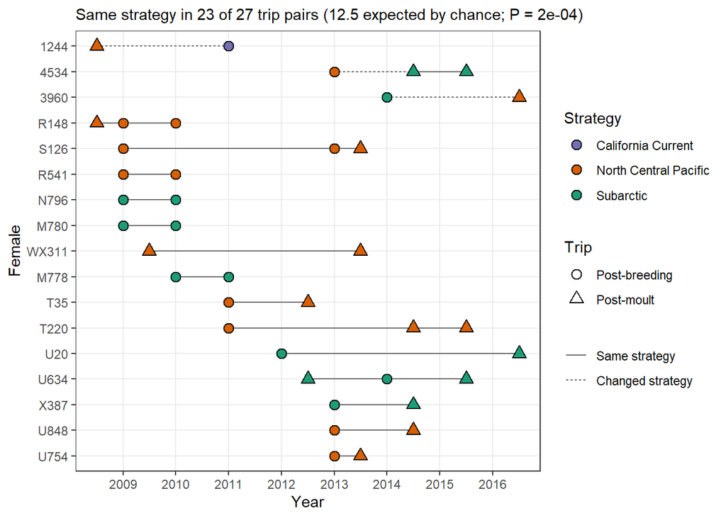

```r
STRAT_COLS <- c(Subarctic = "#1b9e77", `North Central Pacific` = "#d95f02",
                `California Current` = "#7570b3")
seq_d <- trk %>%
  filter(MainID %in% rep_ids, !is.na(strategy)) %>%
  mutate(MainID = as.character(MainID),
         x = year + ifelse(trip == "PM", 0.5, 0)) %>%
  arrange(MainID, x)
segs <- seq_d %>% group_by(MainID) %>%
  mutate(xend = dplyr::lead(x), s_next = dplyr::lead(strategy)) %>%
  filter(!is.na(xend)) %>% ungroup() %>%
  mutate(change = factor(ifelse(strategy == s_next, "Same strategy", "Changed strategy"),
                         c("Same strategy", "Changed strategy")))
ord <- seq_d %>% group_by(MainID) %>%
  summarise(changed = n_distinct(strategy) > 1, first = min(x)) %>%
  arrange(changed, desc(first)) %>% pull(MainID)          # changers at the top
seq_d$MainID <- factor(seq_d$MainID, ord)
segs$MainID  <- factor(segs$MainID, ord)

all_row <- fid_tab[fid_tab$pair_type == "All pairs", ]
g_seq <- ggplot() +
  geom_segment(data = segs, aes(x = x, xend = xend, y = MainID, yend = MainID, linetype = change),
               colour = "grey40") +
  geom_point(data = seq_d, aes(x, MainID, fill = strategy, shape = trip), size = 3, stroke = 0.6) +
  scale_fill_manual(values = STRAT_COLS, name = "Strategy",
                    guide = guide_legend(override.aes = list(shape = 21))) +
  scale_shape_manual(values = c(PB = 21, PM = 24), name = "Trip",
                     labels = c(PB = "Post-breeding", PM = "Post-moult")) +
  scale_linetype_manual(values = c(`Same strategy` = "solid", `Changed strategy` = "22"),
                        name = NULL, drop = FALSE) +
  scale_x_continuous(breaks = seq(min(seq_d$year), max(seq_d$year) + 1, 1)) +
  theme_bw() + theme(panel.grid.minor = element_blank(), panel.grid.major.y = element_line(colour = "grey93")) +
  labs(x = "Year", y = "Female",
       subtitle = sprintf("Same strategy in %d of %d trip pairs (%.1f expected by chance; P = %s)",
                          all_row$n_same, all_row$n_pairs, all_row$expected, signif(all_row$P, 2)))
g_seq
```

```r
ggsave(file.path(FIG, "1_strategy_sequences.pdf"), g_seq, width = 7, height = 5)
```

# 5 2. Behavioural repeatability

## 5.1 A common behavioural space for both trip types

Variables are standardised **within trip type** before the PCA, so the axes describe how a female differs from other females on the same kind of trip, rather than the large difference between Post-Breeding and Post-Moult trips.

```r
Z <- trk %>% group_by(trip) %>% mutate(across(all_of(BEHAV), ~ as.numeric(scale(.x)))) %>%
  ungroup() %>% dplyr::select(all_of(BEHAV))
pca_all <- prcomp(Z, center = TRUE, scale. = FALSE)
trk$Dim1 <- pca_all$x[, 1]; trk$Dim2 <- pca_all$x[, 2]
# Orient: Dim1 positive = higher latitude; Dim2 positive = longer dives (diving-effort axis)
if (cor(trk$Dim1, trk$MaxLat_degrees) < 0) trk$Dim1 <- -trk$Dim1
if (cor(trk$Dim2, trk$Mean_Duration_sec) < 0) trk$Dim2 <- -trk$Dim2
round(100 * summary(pca_all)$importance[2, 1:4], 1)
```

```
##  PC1  PC2  PC3  PC4
## 29.4 14.9 11.6 10.4
```

```r
ax <- sapply(c("Dim1", "Dim2"), function(d) cor(trk[BEHAV], trk[[d]])[, 1])
lapply(c(Dim1 = "Dim1", Dim2 = "Dim2"), function(d) {
  r <- ax[, d]; round(sort(r[abs(r) >= 0.5], decreasing = TRUE), 2) })
```

```
## $Dim1
##    DeepDayForageDivesMedian_m                MaxLat_degrees
##                          0.76                          0.75
## MesoEcoProportionSubArcticPac                  Mean_Depth_m
##                          0.69                         -0.64
##            SdDistContShelf_km    MesoEcoProportionNorthCPac
##                         -0.84                         -0.87
##      MedianDistToContShelf_km
##                         -0.88
##
## $Dim2
## Mean_Duration_sec     PctTripDiving  Pct_TransitDives
##              0.69              0.57             -0.70
```

## 5.2 Individual trajectories

Each line joins the trips of one repeat female (points coloured by trip type). Flat lines = consistent females.

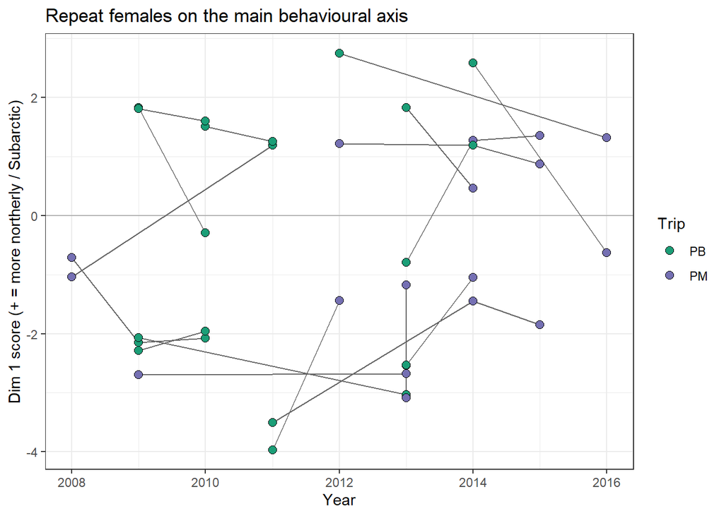

```r
traj <- trk %>% filter(MainID %in% rep_ids) %>% arrange(MainID, year)
g <- ggplot(traj, aes(year, Dim1, group = MainID)) +
  geom_hline(yintercept = 0, colour = "grey70") +
  geom_line(colour = "grey40") + geom_point(aes(fill = trip), shape = 21, size = 2.5) +
  scale_fill_manual(values = c(PB = "#1b9e77", PM = "#7570b3"), name = "Trip") +
  theme_bw() + labs(x = "Year", y = "Dim 1 score (+ = more northerly / Subarctic)",
                    title = "Repeat females on the main behavioural axis")
g
```

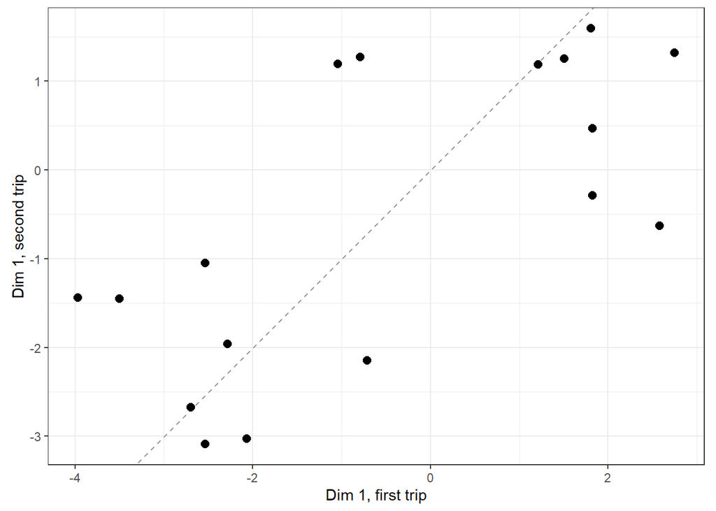

```r
ggsave(file.path(FIG, "2_trajectories_Dim1.pdf"), g, width = 7, height = 5)

g2 <- trk %>% filter(MainID %in% rep_ids) %>%
  group_by(MainID) %>% mutate(order = rank(year, ties.method = "first")) %>%
  dplyr::select(MainID, order, Dim1) %>% filter(order <= 2) %>%
  pivot_wider(names_from = order, values_from = Dim1, names_prefix = "trip_") %>%
  ggplot(aes(trip_1, trip_2)) + geom_abline(linetype = 2, colour = "grey60") +
  geom_point(size = 2.5) + coord_equal() + theme_bw() +
  labs(x = "Dim 1, first trip", y = "Dim 1, second trip")
g2
```

## 5.3 Repeatability (rptR)

Model: `y ~ Trip + (1 | MainID) + (1 | Year)`. R is the adjusted repeatability (between-female variance over the sum of the random-effect and residual variances, with trip type as a fixed effect). All tracked females are used; females tracked once help estimate the variance components, but the between-female variance is informed by the repeat females (17 here), so CIs are wide.

```r
qlogit <- function(p) { e <- 0.005; qlogis(pmin(pmax(p, e), 1 - e)) }
trk <- trk %>% mutate(MainID = factor(MainID), Year = factor(year), Trip = factor(trip),
                      logit_CAC = qlogit(MesoEcoProportionCAC),
                      log_dist_shelf = log(MedianDistToContShelf_km + 1))
beh_vars <- c(`Dim 1 (latitude / offshore axis)` = "Dim1",
              `Dim 2 (diving-effort axis)` = "Dim2",
              `Maximum latitude` = "MaxLat_degrees",
              `California Current use (logit)` = "logit_CAC",
              `Distance to shelf (log)` = "log_dist_shelf")

set.seed(SEED)
rpt_beh <- bind_rows(lapply(names(beh_vars), function(nm) {
  v <- beh_vars[[nm]]
  r <- fit_rpt(reformulate(c("Trip", "(1 | MainID)", "(1 | Year)"), v),
           grname = c("MainID", "Year"), data = trk, datatype = "Gaussian",
           nboot = N_RPT_BOOT, npermut = N_RPT_PERM)
  rpt_row(r, nm, nrow(trk), nlevels(trk$MainID), length(rep_ids))
}))
rpt_beh %>% mutate(across(where(is.double), ~ signif(.x, 3)))
```

```
##                           variable n_obs n_females n_repeat_females     R
## 1 Dim 1 (latitude / offshore axis)   179       157               17 0.785
## 2       Dim 2 (diving-effort axis)   179       157               17 0.264
## 3                 Maximum latitude   179       157               17 0.843
## 4   California Current use (logit)   179       157               17 0.640
## 5          Distance to shelf (log)   179       157               17 0.775
##       SE   lwr   upr P_LRT P_permut R_year P_LRT_year
## 1 0.0693 0.631 0.891 0.000    0.001 0.0389      0.051
## 2 0.1770 0.000 0.616 0.124    0.140 0.0000      1.000
## 3 0.0548 0.702 0.922 0.000    0.001 0.0000      1.000
## 4 0.1200 0.369 0.819 0.002    0.078 0.0000      0.500
## 5 0.0741 0.600 0.892 0.000    0.003 0.0192      0.192
```

```r
write.csv(rpt_beh, file.path(OUT, "2_behaviour_repeatability.csv"), row.names = FALSE)
```

**Within one trip type.** Estimated only when at least `MIN_REP_WITHIN` females were tracked twice on that trip type; with fewer, the model cannot separate within- from between-female variance and R is meaningless (it tends to 1).

```r
set.seed(SEED)
rpt_within <- bind_rows(lapply(c("PB", "PM"), function(tp) {
  d <- trk %>% filter(trip == tp) %>% droplevels()
  n_rep <- sum(table(d$MainID) > 1)
  if (n_rep < MIN_REP_WITHIN) {
    message("Within ", tp, ": only ", n_rep, " repeat females - repeatability not estimated")
    return(NULL)
  }
  r <- tryCatch(fit_rpt(Dim1 ~ (1 | MainID) + (1 | Year), grname = c("MainID", "Year"), data = d,
                    datatype = "Gaussian", nboot = N_RPT_BOOT, npermut = N_RPT_PERM),
                error = function(e) NULL)
  if (is.null(r)) return(NULL)
  rpt_row(r, paste("Dim 1, within", tp), nrow(d), nlevels(d$MainID), n_rep)
}))
rpt_within
```

```
##           variable n_obs n_females n_repeat_females    R     SE   lwr   upr
## 1 Dim 1, within PB    93        87                6 0.82 0.0909 0.623 0.968
##   P_LRT P_permut R_year P_LRT_year
## 1 0.001    0.007  0.108      0.012
```

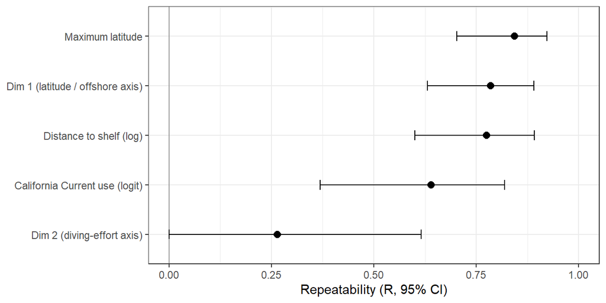

```r
g <- ggplot(rpt_beh, aes(R, reorder(variable, R))) +
  geom_vline(xintercept = 0, colour = "grey60") +
  geom_errorbar(aes(xmin = lwr, xmax = upr), width = 0.2, orientation = "y") + geom_point(size = 2.5) +
  coord_cartesian(xlim = c(0, 1)) + theme_bw() +
  labs(x = "Repeatability (R, 95% CI)", y = NULL)
g
```

```r
ggsave(file.path(FIG, "2_behaviour_repeatability.pdf"), g, width = 7, height = 3.5)
```

# 6 3. Spatial fidelity

Bhattacharyya’s affinity (BA) between the utilisation distributions of two trips of the same female, compared with BA between trips of different females of the same pair type. Two nulls:

- **Population null**: the second trip is replaced by a random trip of the same type from a different female. Tests whether females return to *their own* areas rather than just to the population’s area.
- **Strategy null** (same-type pairs only): the replacement trip is drawn from the same strategy. Tests fidelity *beyond* strategy membership.

```
## 23 within-female trip pairs with UDs
##
## PB-PB PB-PM PM-PM
##     5    14     4
##   pair_type n_pairs BA_same_female BA_null_population P_population
## 1     PB-PB       5          0.809              0.299       0.0001
## 2     PB-PM      14          0.351              0.246       0.0119
## 3     PM-PM       4          0.597              0.235       0.0001
## 4 All pairs      23          0.493              0.255       0.0001
##   BA_null_strategy P_strategy
## 1            0.463      1e-04
## 2               NA         NA
## 3            0.335      1e-04
## 4               NA         NA
```

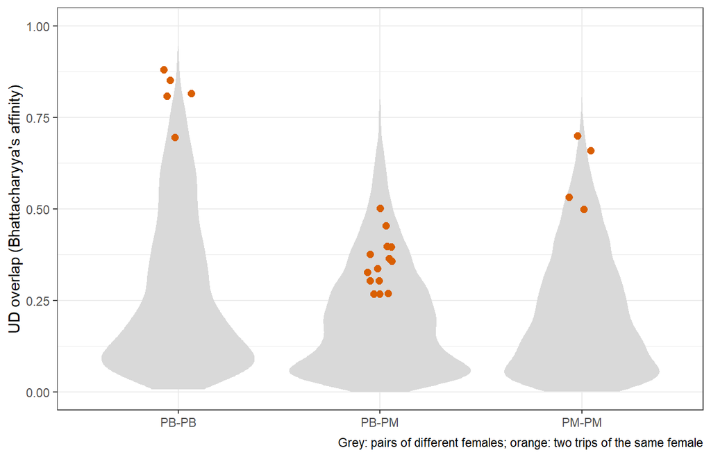

```r
if (file.exists(UD_FILE)) {
  ud <- readRDS(UD_FILE)
  P  <- cbind(ud$P_pb, ud$P_pm)
  ud_meta <- bind_rows(ud$seals_pb %>% transmute(TOPPID, trip = "PB", strategy),
                       ud$seals_pm %>% transmute(TOPPID, trip = "PM", strategy)) %>%
    left_join(trk %>% transmute(TOPPID, MainID = as.character(MainID)), by = "TOPPID") %>%
    filter(!is.na(MainID))
  P  <- P[, ud_meta$TOPPID, drop = FALSE]
  BA <- crossprod(sqrt(P))

  sp <- pairs_trk %>% filter(TOPPID_1 %in% ud_meta$TOPPID, TOPPID_2 %in% ud_meta$TOPPID) %>%
    mutate(BA = BA[cbind(TOPPID_1, TOPPID_2)])
  cat(nrow(sp), "within-female trip pairs with UDs\n"); print(table(sp$pair_type))

  # Candidate replacement trips for the second member of each pair
  fem   <- setNames(ud_meta$MainID, ud_meta$TOPPID)
  tripv <- setNames(ud_meta$trip, ud_meta$TOPPID)
  strv  <- setNames(ud_meta$strategy, ud_meta$TOPPID)
  cand_pop <- lapply(seq_len(nrow(sp)), function(k)
    ud_meta$TOPPID[ud_meta$trip == tripv[sp$TOPPID_2[k]] & ud_meta$MainID != sp$MainID[k]])
  cand_str <- lapply(seq_len(nrow(sp)), function(k)
    ud_meta$TOPPID[ud_meta$trip == tripv[sp$TOPPID_2[k]] & ud_meta$MainID != sp$MainID[k] &
                   ud_meta$strategy == strv[sp$TOPPID_2[k]]])

  randomise <- function(cands, rows) {
    set.seed(SEED)
    replicate(N_PERM, {
      j  <- vapply(cands[rows], function(cc) if (length(cc)) pick1(cc) else NA_character_, "")
      ok <- !is.na(j)
      mean(BA[cbind(sp$TOPPID_1[rows][ok], j[ok])])
    })
  }
  sp_tab <- bind_rows(lapply(c(sort(unique(sp$pair_type)), "All pairs"), function(tp) {
    rows <- if (tp == "All pairs") seq_len(nrow(sp)) else which(sp$pair_type == tp)
    obs  <- mean(sp$BA[rows])
    n_pop <- randomise(cand_pop, rows)
    n_str <- if (tp %in% c("PB-PB", "PM-PM")) randomise(cand_str, rows) else NA
    data.frame(pair_type = tp, n_pairs = length(rows), BA_same_female = obs,
               BA_null_population = mean(n_pop), P_population = (1 + sum(n_pop >= obs)) / (N_PERM + 1),
               BA_null_strategy = if (all(is.na(n_str))) NA else mean(n_str),
               P_strategy = if (all(is.na(n_str))) NA else (1 + sum(n_str >= obs)) / (N_PERM + 1))
  }))
  print(sp_tab %>% mutate(across(where(is.double), ~ signif(.x, 3))))
  write.csv(sp_tab, file.path(OUT, "3_spatial_fidelity.csv"), row.names = FALSE)

  # Figure: BA for same-female pairs vs all different-female pairs of the same type
  ij <- which(upper.tri(BA), arr.ind = TRUE)
  allp <- data.frame(a = colnames(BA)[ij[, 1]], b = colnames(BA)[ij[, 2]], BA = BA[ij]) %>%
    mutate(fa = fem[a], fb = fem[b], ta = tripv[a], tb = tripv[b],
           pair_type = ifelse(ta == tb, paste0(ta, "-", tb), "PB-PM")) %>%
    filter(fa != fb) %>% mutate(which = "Different females")
  g <- ggplot() +
    geom_violin(data = allp, aes(pair_type, BA), fill = "grey85", colour = NA) +
    geom_jitter(data = sp, aes(pair_type, BA), width = 0.08, height = 0, size = 2.2, colour = "#d95f02") +
    theme_bw() + coord_cartesian(ylim = c(0, 1)) +
    labs(x = NULL, y = "UD overlap (Bhattacharyya's affinity)",
         caption = "Grey: pairs of different females; orange: two trips of the same female")
  print(g)
  ggsave(file.path(FIG, "3_spatial_fidelity.pdf"), g, width = 7, height = 4.5)
} else {
  message("Run NESE_SpatialStrategies.Rmd first: ", UD_FILE, " not found.")
}
```

# 7 4. Isotopic consistency

## 7.1 Data

The same sample set as the previous script: arrival samples of females, with the same exclusions.

```r
iso_raw <- if (file.exists(REPEAT_DATA)) readRDS(REPEAT_DATA) else read.csv(META_FILE)
stopifnot(all(c("MainID", "Sex", "TimePeriod", "Trip", "ProcedureYear", ISO) %in% names(iso_raw)))
iso <- iso_raw %>%
  filter(Sex == "Female", TimePeriod == "Arrival", !is.na(d13C), !is.na(d15N),
         !MainID %in% ISO_EXCLUDE) %>%
  transmute(MainID = factor(as.character(MainID)),
            trip = unname(TRIP_LAB[as.character(Trip)]), Trip = factor(trip),
            year = as.integer(as.character(ProcedureYear)), Year = factor(year),
            d13C, d15N) %>%
  filter(!is.na(trip))
iso_rep <- names(which(table(iso$MainID) > 1))
cat(nrow(iso), "samples from", nlevels(iso$MainID), "females;", length(iso_rep),
    "females sampled more than once\n")
```

```
## 259 samples from 197 females; 47 females sampled more than once
```

```r
table(table(iso$MainID))
```

```
##
##   1   2   3   4
## 150  33  13   1
```

## 7.2 Population-level repeatability

Three specifications, from the original to the recommended one:

- 1. **original**: repeat females only, `y ~ Trip + (1 | MainID)`;
- 2. all females, same model;
- 3. **recommended**: all females, `y ~ Trip + (1 | MainID) + (1 | Year)`, which removes consistency that is only due to shared isotopic baselines in similar years.

```r
set.seed(SEED)
rpt_iso <- bind_rows(lapply(ISO, function(v) {
  d_rep <- iso %>% filter(MainID %in% iso_rep) %>% droplevels()
  ra <- fit_rpt(reformulate(c("Trip", "(1 | MainID)"), v), grname = "MainID", data = d_rep,
            datatype = "Gaussian", nboot = N_RPT_BOOT, npermut = N_RPT_PERM)
  rb <- fit_rpt(reformulate(c("Trip", "(1 | MainID)"), v), grname = "MainID", data = iso,
            datatype = "Gaussian", nboot = N_RPT_BOOT, npermut = N_RPT_PERM)
  rc <- fit_rpt(reformulate(c("Trip", "(1 | MainID)", "(1 | Year)"), v), grname = c("MainID", "Year"),
            data = iso, datatype = "Gaussian", nboot = N_RPT_BOOT, npermut = N_RPT_PERM)
  bind_rows(
    rpt_row(ra, paste(v, "(a) repeat females, no year"), nrow(d_rep), nlevels(d_rep$MainID), length(iso_rep)),
    rpt_row(rb, paste(v, "(b) all females, no year"), nrow(iso), nlevels(iso$MainID), length(iso_rep)),
    rpt_row(rc, paste(v, "(c) all females, year random"), nrow(iso), nlevels(iso$MainID), length(iso_rep)))
}))
rpt_iso %>% mutate(across(where(is.double), ~ signif(.x, 3)))
```

```
##                            variable n_obs n_females n_repeat_females     R
## 1  d13C (a) repeat females, no year   109        47               47 0.773
## 2     d13C (b) all females, no year   259       197               47 0.766
## 3 d13C (c) all females, year random   259       197               47 0.753
## 4  d15N (a) repeat females, no year   109        47               47 0.754
## 5     d15N (b) all females, no year   259       197               47 0.769
## 6 d15N (c) all females, year random   259       197               47 0.766
##       SE   lwr   upr P_LRT P_permut R_year P_LRT_year
## 1 0.0577 0.627 0.859     0    0.001     NA         NA
## 2 0.0475 0.661 0.848     0    0.001     NA         NA
## 3 0.0481 0.644 0.830     0    0.001 0.0216      0.072
## 4 0.0611 0.609 0.850     0    0.001     NA         NA
## 5 0.0468 0.665 0.846     0    0.001     NA         NA
## 6 0.0471 0.665 0.848     0    0.001 0.0367      0.013
```

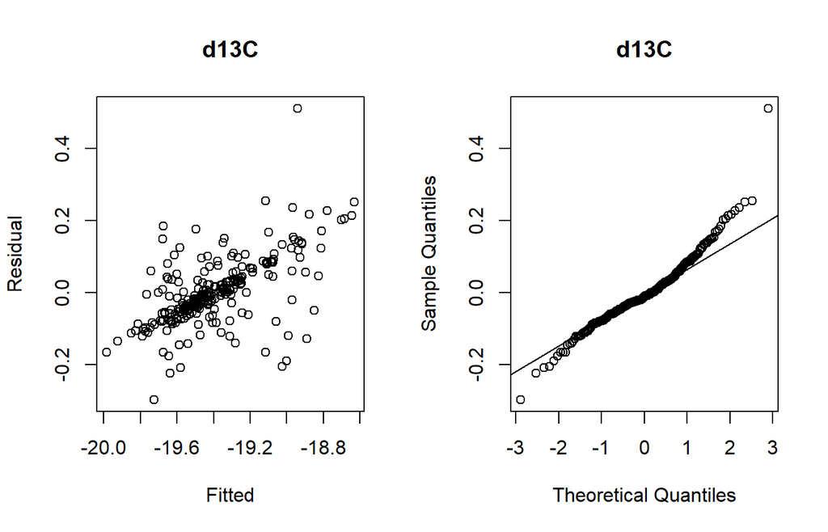

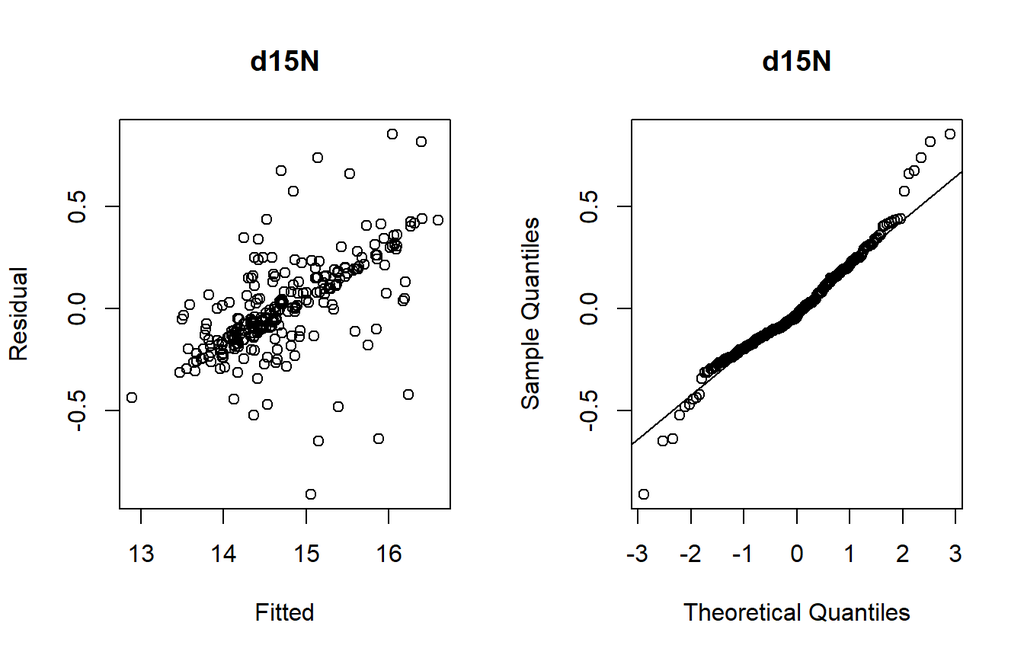

```r
write.csv(rpt_iso, file.path(OUT, "4_isotope_repeatability.csv"), row.names = FALSE)

# Model checks for the recommended model
for (v in ISO) {
  m <- lmer(reformulate(c("Trip", "(1 | MainID)", "(1 | Year)"), v), data = iso)
  par(mfrow = c(1, 2)); plot(fitted(m), resid(m), main = v, xlab = "Fitted", ylab = "Residual")
  qqnorm(resid(m), main = v); qqline(resid(m)); par(mfrow = c(1, 1))
}
```

## 7.3 Within-female differences vs different females in the same years

For every pair of samples from the same female, the absolute isotopic difference is compared with that between two *different* females sampled in the same two years and trip types (same baselines). If females are consistent, their own differences are smaller than these year-matched pairs.

```r
iso_pairs <- within_pairs(iso %>% transmute(MainID = as.character(MainID),
                                            TOPPID = paste0(MainID, "_", row_number()),
                                            trip, year))
iso_key <- iso %>% mutate(key = paste0(as.character(MainID), "_", row_number()))
val <- iso_key %>% dplyr::select(key, d13C, d15N)
iso_pairs <- iso_pairs %>%
  mutate(d13C_1 = val$d13C[match(TOPPID_1, val$key)], d13C_2 = val$d13C[match(TOPPID_2, val$key)],
         d15N_1 = val$d15N[match(TOPPID_1, val$key)], d15N_2 = val$d15N[match(TOPPID_2, val$key)],
         abs_d13C = abs(d13C_1 - d13C_2), abs_d15N = abs(d15N_1 - d15N_2))
cat(nrow(iso_pairs), "within-female sample pairs\n")
```

```
## 78 within-female sample pairs
```

```r
# Candidate samples from other females with the same year and trip type (fallback: same trip type)
pool <- iso_key %>% transmute(key, MainID = as.character(MainID), trip, year, d13C, d15N)
cands <- function(fem, tp, yr) {
  c1 <- which(pool$MainID != fem & pool$trip == tp & pool$year == yr)
  if (length(c1)) c1 else which(pool$MainID != fem & pool$trip == tp)
}
c1 <- lapply(seq_len(nrow(iso_pairs)), function(k) cands(iso_pairs$MainID[k], iso_pairs$trip_1[k], iso_pairs$year_1[k]))
c2 <- lapply(seq_len(nrow(iso_pairs)), function(k) cands(iso_pairs$MainID[k], iso_pairs$trip_2[k], iso_pairs$year_2[k]))

set.seed(SEED)
null_iso <- replicate(N_PERM, {
  d <- vapply(seq_len(nrow(iso_pairs)), function(k) {
    a <- pick1(c1[[k]])
    b_c <- c2[[k]][pool$MainID[c2[[k]]] != pool$MainID[a]]
    if (!length(b_c)) return(c(NA_real_, NA_real_))
    b <- pick1(b_c)
    c(abs(pool$d13C[a] - pool$d13C[b]), abs(pool$d15N[a] - pool$d15N[b]))
  }, numeric(2))
  rowMeans(d, na.rm = TRUE)
})
iso_tab <- data.frame(isotope = ISO,
  mean_abs_diff_same_female = c(mean(iso_pairs$abs_d13C), mean(iso_pairs$abs_d15N)),
  mean_abs_diff_year_matched_null = rowMeans(null_iso),
  P = c((1 + sum(null_iso[1, ] <= mean(iso_pairs$abs_d13C))) / (N_PERM + 1),
        (1 + sum(null_iso[2, ] <= mean(iso_pairs$abs_d15N))) / (N_PERM + 1)))
iso_tab %>% mutate(across(where(is.double), ~ signif(.x, 3)))
```

```
##   isotope mean_abs_diff_same_female mean_abs_diff_year_matched_null     P
## 1    d13C                     0.162                           0.337 1e-04
## 2    d15N                     0.448                           0.946 1e-04
```

```r
write.csv(iso_tab, file.path(OUT, "4_isotope_pair_differences.csv"), row.names = FALSE)
```

## 7.4 Does consistency decline with time between samples?

```r
lag_tests <- sapply(c(d13C = "abs_d13C", d15N = "abs_d15N"), function(v) {
  ct <- cor.test(iso_pairs$lag_years, iso_pairs[[v]], method = "spearman", exact = FALSE)
  c(rho = unname(ct$estimate), P = ct$p.value)
})
round(lag_tests, 3)
```

```
##      d13C  d15N
## rho 0.043 0.255
## P   0.708 0.024
```

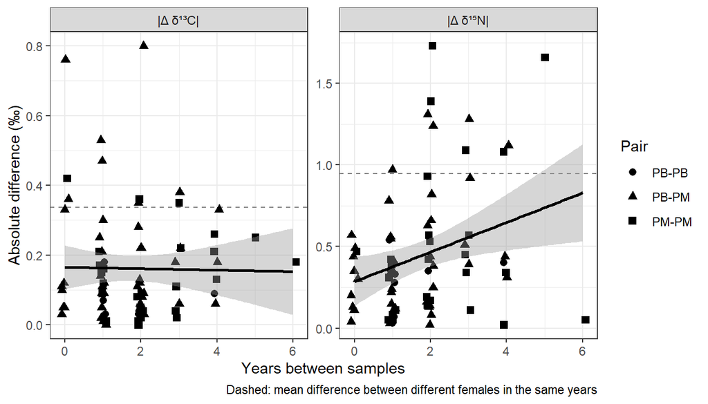

```r
g <- iso_pairs %>% dplyr::select(lag_years, pair_type, abs_d13C, abs_d15N) %>%
  pivot_longer(c(abs_d13C, abs_d15N), names_to = "isotope", values_to = "diff") %>%
  mutate(isotope = recode(isotope, abs_d13C = "|Δ δ¹³C|", abs_d15N = "|Δ δ¹⁵N|")) %>%
  ggplot(aes(lag_years, diff)) +
  geom_hline(data = data.frame(isotope = c("|Δ δ¹³C|", "|Δ δ¹⁵N|"),
                               y = rowMeans(null_iso)),
             aes(yintercept = y), linetype = 2, colour = "grey50") +
  geom_jitter(aes(shape = pair_type), width = 0.1, height = 0, size = 2.2) +
  geom_smooth(method = "lm", formula = y ~ x, colour = "black", se = TRUE) +
  facet_wrap(~ isotope, scales = "free_y") + theme_bw() +
  labs(x = "Years between samples", y = "Absolute difference (‰)", shape = "Pair",
       caption = "Dashed: mean difference between different females in the same years")
g
```

```r
ggsave(file.path(FIG, "4_isotope_differences_vs_lag.pdf"), g, width = 8, height = 4, device = cairo_pdf)
```

# 8 Summary

```r
list(
  strategy_fidelity = fid_tab,
  kappa = kap,
  behaviour_repeatability = rpt_beh %>% dplyr::select(variable, R, lwr, upr, P_LRT, P_permut),
  spatial_fidelity = if (exists("sp_tab")) sp_tab else "UDs not available",
  isotope_repeatability = rpt_iso %>% dplyr::select(variable, R, lwr, upr, P_LRT),
  isotope_pairs = iso_tab,
  isotope_lag = round(lag_tests, 3))
```

```
## $strategy_fidelity
##   pair_type n_pairs n_same  expected      P
## 1     PB-PB       6      6  2.626463 0.0066
## 2     PB-PM      17     13  7.857286 0.0110
## 3     PM-PM       4      4  1.996200 0.0608
## 4 All pairs      27     23 12.479948 0.0002
##
## $kappa
## # A tibble: 2 × 3
##   pair_type     n kappa
##   <chr>     <int> <dbl>
## 1 PB-PB         6     1
## 2 PM-PM         4     1
##
## $behaviour_repeatability
##                           variable     R   lwr   upr P_LRT P_permut
## 1 Dim 1 (latitude / offshore axis) 0.785 0.631 0.891 0.000    0.001
## 2       Dim 2 (diving-effort axis) 0.264 0.000 0.616 0.124    0.140
## 3                 Maximum latitude 0.843 0.702 0.922 0.000    0.001
## 4   California Current use (logit) 0.640 0.369 0.819 0.002    0.078
## 5          Distance to shelf (log) 0.775 0.600 0.892 0.000    0.003
##
## $spatial_fidelity
##   pair_type n_pairs BA_same_female BA_null_population P_population
## 1     PB-PB       5      0.8094543          0.2994288       0.0001
## 2     PB-PM      14      0.3507235          0.2461437       0.0119
## 3     PM-PM       4      0.5965765          0.2345466       0.0001
## 4 All pairs      23      0.4932046          0.2551620       0.0001
##   BA_null_strategy P_strategy
## 1        0.4631891      1e-04
## 2               NA         NA
## 3        0.3354090      1e-04
## 4               NA         NA
##
## $isotope_repeatability
##                            variable     R   lwr   upr P_LRT
## 1  d13C (a) repeat females, no year 0.773 0.627 0.859     0
## 2     d13C (b) all females, no year 0.766 0.661 0.848     0
## 3 d13C (c) all females, year random 0.753 0.644 0.830     0
## 4  d15N (a) repeat females, no year 0.754 0.609 0.850     0
## 5     d15N (b) all females, no year 0.769 0.665 0.846     0
## 6 d15N (c) all females, year random 0.766 0.665 0.848     0
##
## $isotope_pairs
##   isotope mean_abs_diff_same_female mean_abs_diff_year_matched_null     P
## 1    d13C                 0.1617949                       0.3374024 1e-04
## 2    d15N                 0.4476923                       0.9456389 1e-04
##
## $isotope_lag
##      d13C  d15N
## rho 0.043 0.255
## P   0.708 0.024
```

# 9 Suggested Methods text

*We assessed whether females tracked on more than one trip kept their foraging pattern with four complementary analyses. (1) Strategy fidelity: for each pair of trips by the same female we recorded whether she used the same strategy (for post-breeding–post-moult pairs, the same offshore region), and compared the number of consistent pairs with a null distribution obtained by permuting strategy labels among trips of the same type (9,999 permutations); we also report Cohen’s κ. (2) Behavioural repeatability: after standardising behavioural variables within trip type, we summarised them by principal component analysis and estimated the adjusted repeatability of the first two components and of maximum latitude, California Current use and distance to the continental shelf with linear mixed models including trip type as a fixed effect and female and year as random effects (rptR; Stoffel et al. 2017; parametric bootstrap CIs and permutation tests). (3) Spatial fidelity: we compared the overlap (Bhattacharyya’s affinity) between utilisation distributions of two trips of the same female with that obtained when one trip was replaced by a random trip of the same type from a different female, and, for pairs of the same trip type, from a different female of the same strategy (9,999 randomisations). (4) Isotopic consistency: we estimated the adjusted repeatability of δ¹³C and δ¹⁵N with trip type as a fixed effect and female and year as random effects, and compared absolute isotopic differences between samples of the same female with those between different females sampled in the same years and trip types (9,999 randomisations).*